# Last words of Texas death row inmates

An exploratory text analysis

Edward Yu

2019-03-23

# Introduction

I found this data via a Kaggle post: https://www.kaggle.com/mykhe1097/last-words-of-death-row-inmates. The original data was taken from: https://www.tdcj.texas.gov/death_row/dr_executed_offenders.html.

The title alone was interesting enough to merit more than a passing glance. I begin with the data setup involving importing and imputation. Following this, I do some cursory exploratory data analysis (EDA) followed by some natural language processing (NLP).

# Data setup

Setting up the data consists of everything involving preparing the data for analysis.

## Import

In general, my initial process is very similar from project to project: import the data, use `glimpse` and `summary` to get an idea of the structure, sort all variables by descending unique levels, and plot the missingness of each variable. I find that even if this information isn’t specifically useful in every case it gives a nice overview of the data.

```r
# import
x <- read_csv("data/Texas Last Statement - CSV.csv")

glimpse(x)
```

```
## Observations: 545
## Variables: 20
## $ Execution           <dbl> 545, 544, 543, 542, 541, 540, 539, 538, 53...
## $ LastName            <chr> "Cardenas", "Pruett", "Preyor", "Bigby", "...
## $ FirstName           <chr> "Ruben", "Robert", "Taichin", "James", "Ro...
## $ TDCJNumber          <dbl> 999275, 999411, 999494, 997, 999145, 99946...
## $ Age                 <dbl> 47, 38, 46, 61, 44, 43, 48, 58, 38, 33, 58...
## $ Race                <chr> "Hispanic", "White", "Black", "White", "Hi...
## $ CountyOfConviction  <chr> "Hidalgo", "Bee", "Bexar", "Tarrant", "Bex...
## $ AgeWhenReceived     <dbl> 28, 22, 34, 36, 22, 30, 37, 45, 21, 24, 40...
## $ EducationLevel      <dbl> 11, 8, 10, 9, 10, 12, 12, 9, 8, NA, 8, NA,...
## $ NativeCounty        <dbl> 1, 0, 0, 0, 0, 0, 0, 1, 0, 0, 0, 0, 0, 0, ...
## $ PreviousCrime       <dbl> 0, 1, 0, 1, 1, 1, 0, 0, 0, 0, 0, NA, 0, 1,...
## $ Codefendants        <dbl> 0, 0, 0, 0, 4, 1, 0, 0, 1, 0, 0, 2, 0, 0, ...
## $ NumberVictim        <dbl> 1, 1, 1, 1, 1, 1, 2, 1, 1, 1, 3, 1, 1, 1, ...
## $ WhiteVictim         <dbl> 0, 1, 1, 1, 0, NA, 1, 1, 0, 1, 2, 1, NA, 1...
## $ HispanicVictim      <dbl> 1, 0, 0, 0, 1, NA, 1, 0, 1, 0, 1, 0, NA, 0...
## $ BlackVictim         <dbl> 0, 0, 0, 0, 0, NA, 1, 0, 0, 0, 0, 0, NA, 0...
## $ `VictimOther Races` <dbl> 0, 0, 0, 0, 0, NA, 0, 0, 0, 0, 0, 0, NA, 0...
## $ FemaleVictim        <dbl> 1, 0, 0, 0, 1, 1, 0, 1, 0, 0, 1, 0, 0, 0, ...
## $ MaleVictim          <dbl> 0, 1, 1, 1, 0, 0, 2, 1, 1, 1, 2, 1, 1, 1, ...
## $ LastStatement       <chr> "This is my statement: My final words. Fir...
```

```r
summary(x)
```

```
##    Execution     LastName          FirstName           TDCJNumber
##  Min.   :  1   Length:545         Length:545         Min.   :   511
##  1st Qu.:137   Class :character   Class :character   1st Qu.:   808
##  Median :273   Mode  :character   Mode  :character   Median :999014
##  Mean   :273                                         Mean   :517422
##  3rd Qu.:409                                         3rd Qu.:999246
##  Max.   :545                                         Max.   :999555
##
##       Age            Race           CountyOfConviction AgeWhenReceived
##  Min.   :24.00   Length:545         Length:545         Min.   :17.00
##  1st Qu.:33.00   Class :character   Class :character   1st Qu.:22.00
##  Median :38.00   Mode  :character   Mode  :character   Median :27.00
##  Mean   :39.34                                         Mean   :28.43
##  3rd Qu.:44.00                                         3rd Qu.:33.00
##  Max.   :67.00                                         Max.   :57.00
##                                                        NA's   :18
##  EducationLevel   NativeCounty    PreviousCrime     Codefendants
##  Min.   : 0.00   Min.   :0.0000   Min.   :0.0000   Min.   : 0.0000
##  1st Qu.: 9.00   1st Qu.:0.0000   1st Qu.:0.0000   1st Qu.: 0.0000
##  Median :10.00   Median :0.0000   Median :1.0000   Median : 0.0000
##  Mean   :10.15   Mean   :0.3682   Mean   :0.5422   Mean   : 0.7369
##  3rd Qu.:12.00   3rd Qu.:1.0000   3rd Qu.:1.0000   3rd Qu.: 1.0000
##  Max.   :16.00   Max.   :6.0000   Max.   :1.0000   Max.   :13.0000
##  NA's   :45      NA's   :29       NA's   :36       NA's   :28
##   NumberVictim    WhiteVictim     HispanicVictim    BlackVictim
##  Min.   :0.000   Min.   :0.0000   Min.   :0.0000   Min.   :0.0000
##  1st Qu.:1.000   1st Qu.:0.0000   1st Qu.:0.0000   1st Qu.:0.0000
##  Median :1.000   Median :1.0000   Median :0.0000   Median :0.0000
##  Mean   :1.395   Mean   :0.9151   Mean   :0.2553   Mean   :0.2033
##  3rd Qu.:2.000   3rd Qu.:1.0000   3rd Qu.:0.0000   3rd Qu.:0.0000
##  Max.   :7.000   Max.   :5.0000   Max.   :4.0000   Max.   :6.0000
##  NA's   :18      NA's   :121      NA's   :122      NA's   :122
##  VictimOther Races  FemaleVictim      MaleVictim     LastStatement
##  Min.   :0.000     Min.   :0.0000   Min.   :0.0000   Length:545
##  1st Qu.:0.000     1st Qu.:0.0000   1st Qu.:0.0000   Class :character
##  Median :0.000     Median :1.0000   Median :1.0000   Mode  :character
##  Mean   :0.026     Mean   :0.6787   Mean   :0.7129
##  3rd Qu.:0.000     3rd Qu.:1.0000   3rd Qu.:1.0000
##  Max.   :3.000     Max.   :6.0000   Max.   :4.0000
##  NA's   :122       NA's   :19       NA's   :19
```

```r
# Find unique levels
x.levels <- cbind(colnames(x),
                  (as.data.frame(sapply(x,function(x) length(unique(x))))))
colnames(x.levels) <- c("var","levels")
row.names(x.levels) <- NULL
x.levels[order(-x.levels[,2]),]
```

|  | var | levels |
| --- | --- | --- |
| 1 | Execution | 545 |
| 4 | TDCJNumber | 545 |
| 2 | LastName | 443 |
| 20 | LastStatement | 432 |
| 3 | FirstName | 262 |
| 7 | CountyOfConviction | 92 |
| 5 | Age | 42 |
| 8 | AgeWhenReceived | 40 |
| 9 | EducationLevel | 16 |
| 12 | Codefendants | 9 |

[output cut: 10 more lines]

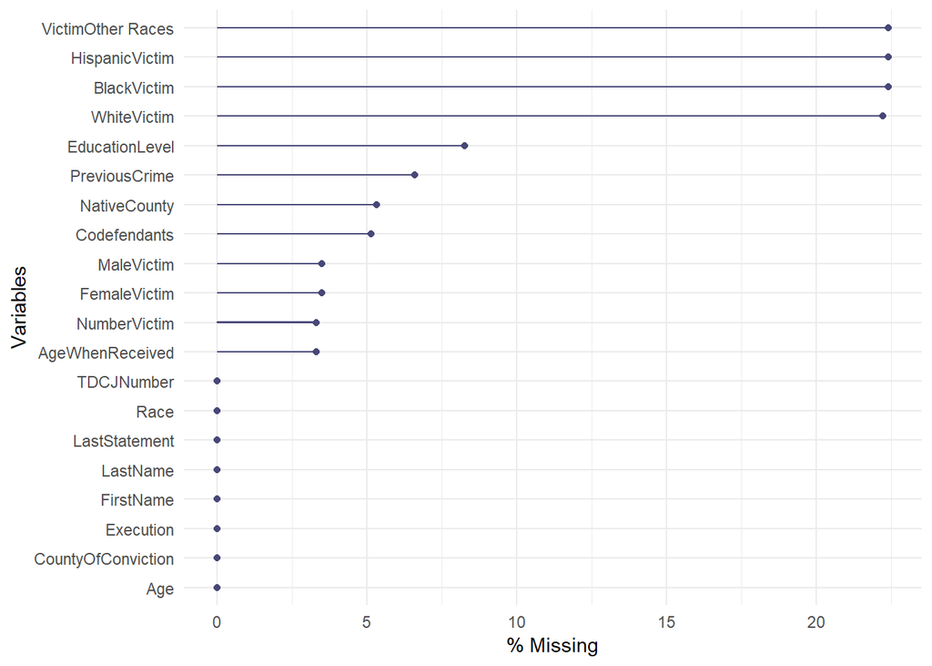

```r
# % missingness using naniar package
gg_miss_var(x, show_pct = T)
```

At this point I can already tell that I’m going to drop the more specific `HispanicVictim` or `BlackVictim` variables in favor of the more generalized `NumberVictim` variable. The `AgeWhenReceived` variable also sounds like it could be an interesting variable to work with paired with `Race` or `Age`.

## Impute

I’ll start by listing all the variables I might be interested in working with.

1. First name
2. Last name
3. Race
4. Education level
5. Previous crime commited?
6. Number of victims
7. Number of female victims
8. Number of male victims
9. Age when received
10. Age executed
11. Codefendants
12. Last statement

Generally we only impute if 5% or less of the data is missing. In this case, `EducationLevel`, `PreviousCrime`, `Codefendants`, are all missing more than 5% of their data. In this case, and for the sake of exploration, I will bend the rule and attempt imputation regardless.

My first analyses used simple median or mean values to replace NA’s. This time around I’ve become interested in a package called `mice`, which stands for Multivariate Imputation by Chained Equations. As my familiarity with the package is limited at this time, I followed the following reference quite closely: https://www.r-bloggers.com/imputing-missing-data-with-r-mice-package/.

The visualizations that follow show the imputed (red) values falling well within actual (blue) values, indicating the imputation was reasonable.

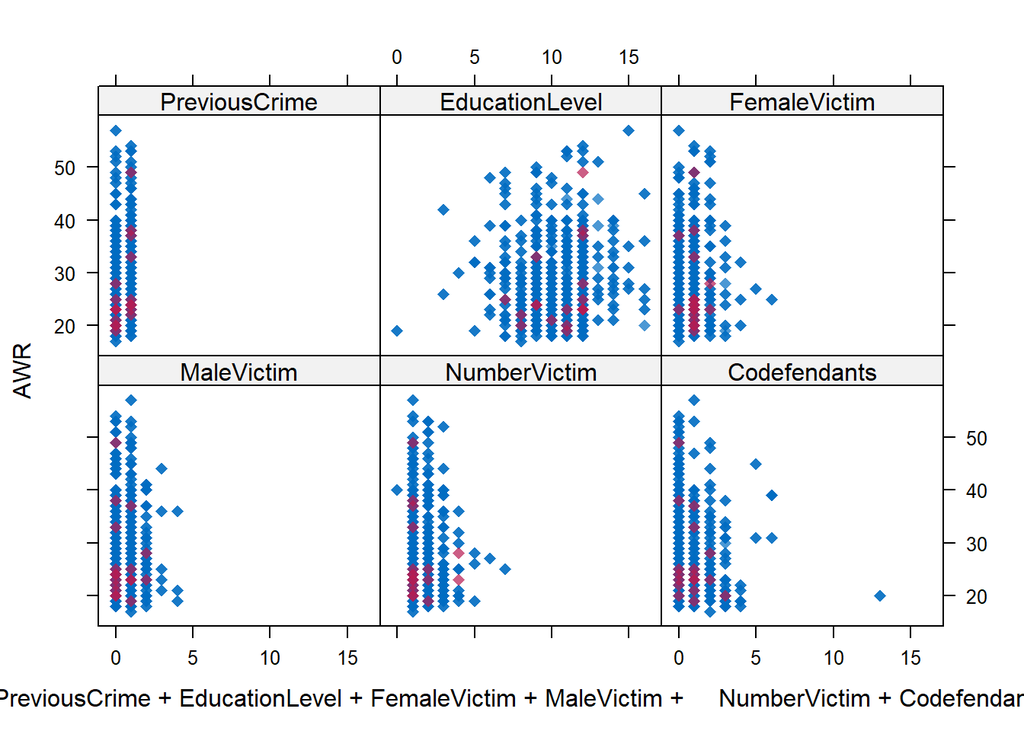

```r
# rename columns, select columns of interest
x1 <- x %>%
  mutate(AWR = AgeWhenReceived) %>%
  mutate(AgeExec = Age) %>%
  select(FirstName,
         LastName,
         Race,
         EducationLevel,
         PreviousCrime,
         NumberVictim,
         FemaleVictim,
         MaleVictim,
         AWR,
         AgeExec,
         Codefendants,
         LastStatement)

# remove columns with characters for stripplot() visualization
rem <- c(1,2,3,12)

# imputation process using pmm, 20 iterations
tempData <- mice(x1[-rem],
                 m=1,
                 maxit=20,
                 meth='pmm',
                 seed=1)

# compare distribution of actual values with imputed values; red=imputed
xyplot(tempData,
       AWR~
         PreviousCrime+
         EducationLevel+
         FemaleVictim+
         MaleVictim+
         NumberVictim+
         Codefendants,
       pch=18,
       cex=1)
```

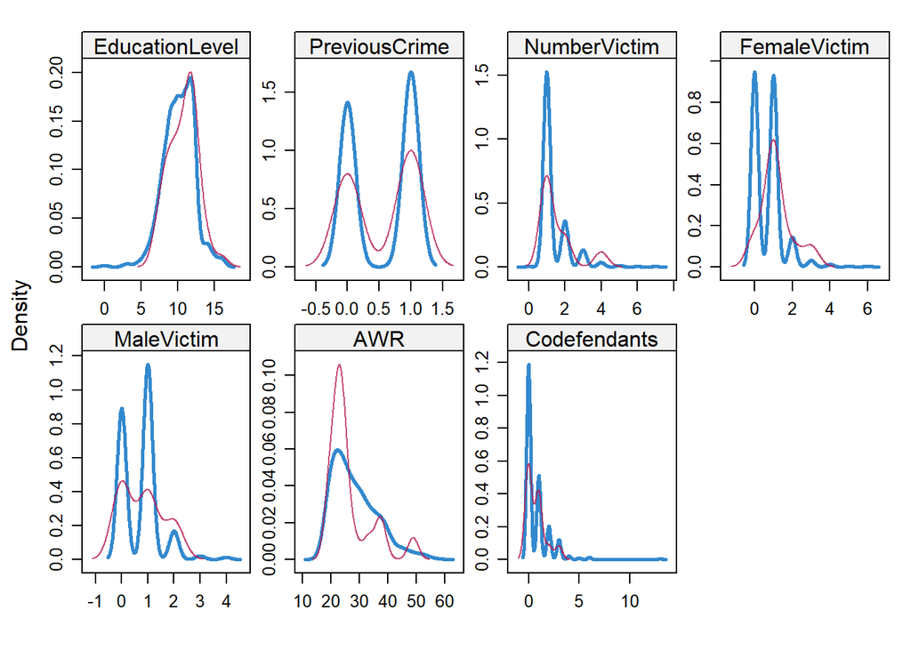

```r
# can also compare using density plot; red=imputed
densityplot(tempData)
```

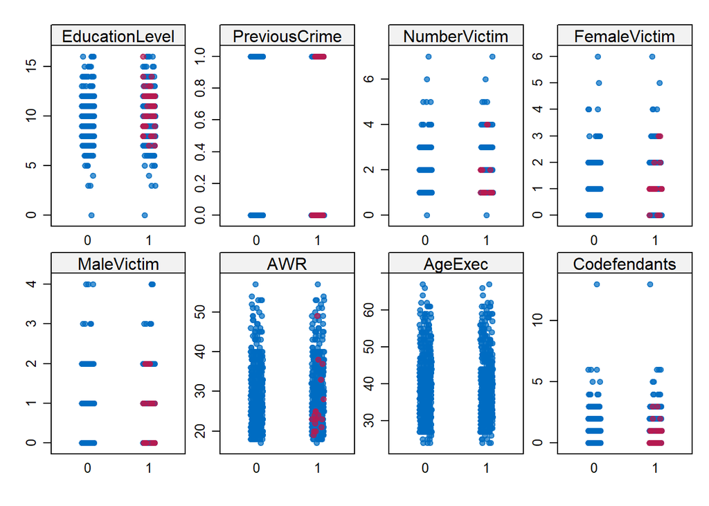

```r
# and stripplot
stripplot(tempData,pch=20,cex=1)
```

```r
# rerun imputation on complete dataset and compare to original
tempData <- mice(x1,m=1,maxit=50,meth='pmm',seed=1)

# replace missing values with imputed values using first dataset
xCom <- complete(tempData,1)
```

Checking the `summary` data of the original dataset and comparing to the new, imputed dataset confirms that our imputed data falls within the distribution of our original data.

```r
# comparing the completed data to the original again shows imputed data makes sense
summary(xCom)[,-rem]
```

```
##  EducationLevel  PreviousCrime     NumberVictim    FemaleVictim
##  Min.   : 0.00   Min.   :0.0000   Min.   :0.000   Min.   :0.0000
##  1st Qu.: 9.00   1st Qu.:0.0000   1st Qu.:1.000   1st Qu.:0.0000
##  Median :10.00   Median :1.0000   Median :1.000   Median :1.0000
##  Mean   :10.12   Mean   :0.5486   Mean   :1.407   Mean   :0.6954
##  3rd Qu.:12.00   3rd Qu.:1.0000   3rd Qu.:2.000   3rd Qu.:1.0000
##  Max.   :16.00   Max.   :1.0000   Max.   :7.000   Max.   :6.0000
##    MaleVictim          AWR           AgeExec       Codefendants
##  Min.   :0.0000   Min.   :17.00   Min.   :24.00   Min.   : 0.0000
##  1st Qu.:0.0000   1st Qu.:22.00   1st Qu.:33.00   1st Qu.: 0.0000
##  Median :1.0000   Median :27.00   Median :38.00   Median : 0.0000
##  Mean   :0.7229   Mean   :28.41   Mean   :39.34   Mean   : 0.7303
##  3rd Qu.:1.0000   3rd Qu.:33.00   3rd Qu.:44.00   3rd Qu.: 1.0000
##  Max.   :4.0000   Max.   :57.00   Max.   :67.00   Max.   :13.0000
```

```r
summary(x1)[,-rem]
```

```
##  EducationLevel  PreviousCrime     NumberVictim    FemaleVictim
##  Min.   : 0.00   Min.   :0.0000   Min.   :0.000   Min.   :0.0000
##  1st Qu.: 9.00   1st Qu.:0.0000   1st Qu.:1.000   1st Qu.:0.0000
##  Median :10.00   Median :1.0000   Median :1.000   Median :1.0000
##  Mean   :10.15   Mean   :0.5422   Mean   :1.395   Mean   :0.6787
##  3rd Qu.:12.00   3rd Qu.:1.0000   3rd Qu.:2.000   3rd Qu.:1.0000
##  Max.   :16.00   Max.   :1.0000   Max.   :7.000   Max.   :6.0000
##  NA's   :45      NA's   :36       NA's   :18      NA's   :19
##    MaleVictim          AWR           AgeExec       Codefendants
##  Min.   :0.0000   Min.   :17.00   Min.   :24.00   Min.   : 0.0000
##  1st Qu.:0.0000   1st Qu.:22.00   1st Qu.:33.00   1st Qu.: 0.0000
##  Median :1.0000   Median :27.00   Median :38.00   Median : 0.0000
##  Mean   :0.7129   Mean   :28.43   Mean   :39.34   Mean   : 0.7369
##  3rd Qu.:1.0000   3rd Qu.:33.00   3rd Qu.:44.00   3rd Qu.: 1.0000
##  Max.   :4.0000   Max.   :57.00   Max.   :67.00   Max.   :13.0000
##  NA's   :19       NA's   :18                      NA's   :28
```

## Fix

I wanted to add a **Time served measurement** , or `Served` measurement. Upon doing this an error in the data presented itself plainly in the `summary` measure which reporeted a value of -1.

```r
# add time served column
xCom <- xCom %>%
  mutate(Served = AgeExec-AWR)

# have an odd -1 years served
summary(xCom$Served)
```

```
##    Min. 1st Qu.  Median    Mean 3rd Qu.    Max.
##   -1.00    8.00   10.00   10.93   13.00   32.00
```

```r
# find datapoint
which.min(xCom$Served)
```

```
## [1] 266
```

```r
xCom[266,]
```

|  | FirstName | LastName | Race | EducationLevel | PreviousCrime | NumberVictim | FemaleVictim | MaleVictim | AWR | AgeExec | Codefendants | LastStatement | Served |
| --- | --- | --- | --- | --- | --- | --- | --- | --- | --- | --- | --- | --- | --- |
| 266 | Tony | Walker | Black | 9 | 1 | 2 | 1 | 1 | 37 | 36 | 0 | Spoken: I would like to say goodbye to a good friend of mine in Switzerland - Diego. I appreciate all the help and support he gave me through the years. A friend of mine in England. Wildflower: I love… | -1 |

```r
# change AgeExec and Served for 266
xCom[266,]$AgeExec <- 47
xCom[266,]$Served <- 10
```

# EDA

We’re ready to do some exploratory data analysis at this point. The most straightforward analyses consist of segregating by racial differences. There are 2 datapoints which are labeled as `Other` for `Race`. We will filter these out because of this.

## Race vs time served

Does race play a part in how many years are served leading up to the execution date? Based on summary data it seems that time served is roughly the same for all races. We can plot density and histogram plots to show the relative and absolute differences in time served between races.

```r
# check races, remove 'other' when plotting
summary(as.factor(x$Race))
```

```
##    Black Hispanic    Other    White
##      198      103        2      242
```

```r
xCom %>%
  filter(Race != "Other") %>%
  group_by(Race) %>%
  summarise(median(Served))
```

| Race | median(Served) |
| --- | --- |
| Black | 11 |
| Hispanic | 10 |
| White | 10 |

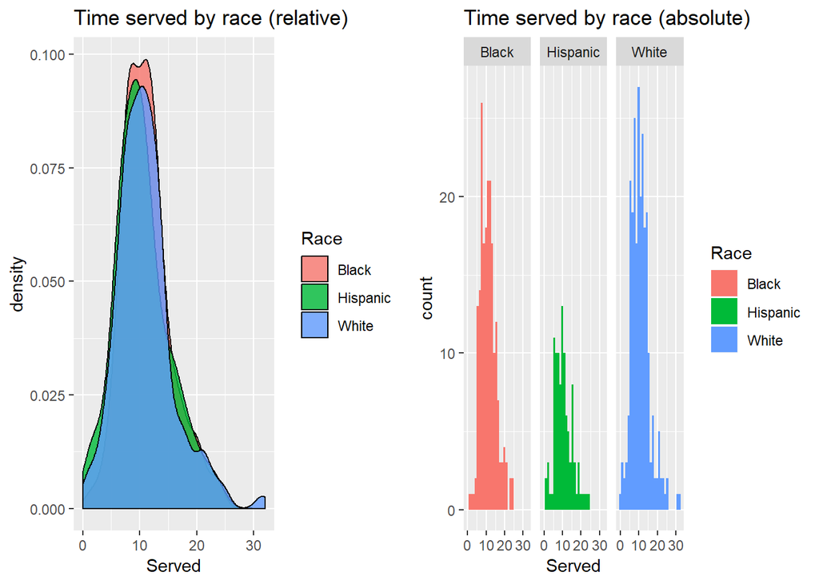

```r
g1 <- xCom %>%
  filter(Race != "Other") %>%
  ggplot(aes(x=Served,fill=Race))+
  geom_density(alpha=.8)+
  ggtitle("Time served by race (relative)")

g2 <- xCom %>%
  filter(Race != "Other") %>%
  ggplot(aes(x=Served,fill=Race))+
  geom_histogram()+
  facet_wrap(Race~.)+
  ggtitle("Time served by race (absolute)")

grid.arrange(g1,g2,nrow=1)
```

We see clearly, based on the density plot, that time served between the different races represented are very similar. When we look at the histogram we do notice there are far fewer hispanics and appear to be slightly more whites in this population.

## Race vs age received, executed

What can we discover about when the inmates were first received and how race impacts this? Along the same vein, does age of execution remain similar between races?

```r
# Age received, executed, served by race
xCom %>%
  filter(Race != "Other") %>%
  group_by(Race) %>%
  summarise(AWR=median(AWR),
            AgeExec=median(AgeExec),
            Served=median(Served))
```

| Race | AWR | AgeExec | Served |
| --- | --- | --- | --- |
| Black | 24.5 | 37 | 11 |
| Hispanic | 25.0 | 36 | 10 |
| White | 29.0 | 40 | 10 |

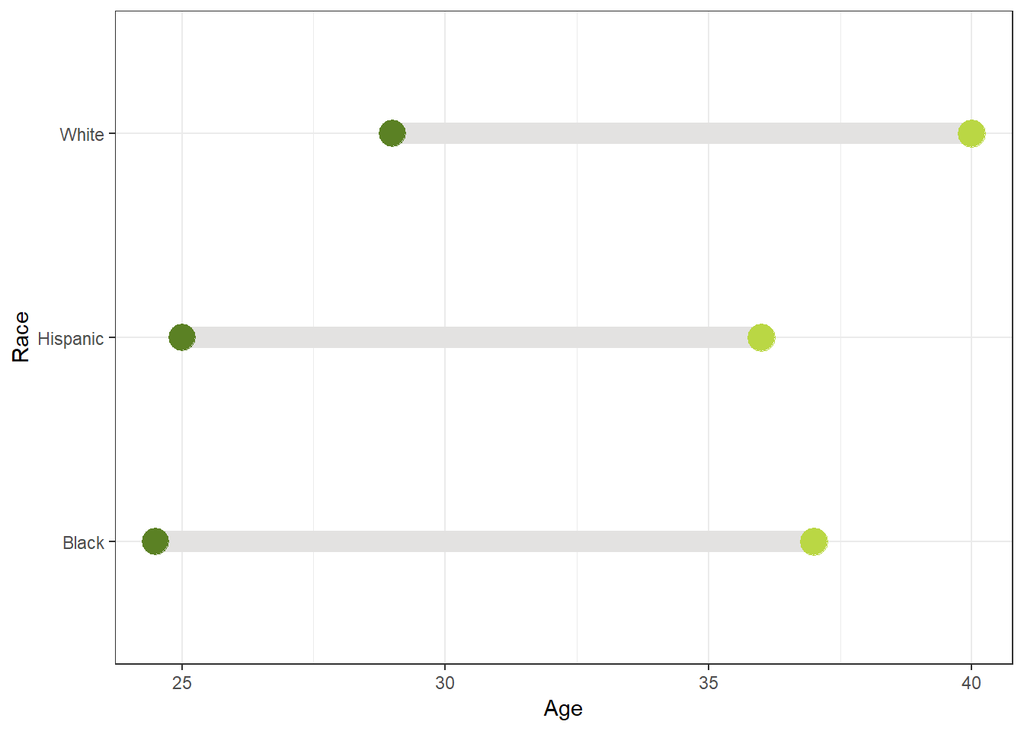

```r
# dumbell summary
df.db <- xCom %>%
  filter(Race != 'Other') %>%
  group_by(Race) %>%
  summarise(AWR=median(AWR),
            AgeExec=median(AgeExec),
            Served=median(Served))

df.db %>%
  ggplot()+
  # geom_segment(aes(y=Race,yend=Race,x=0,xend=1),color="Red",size=.15)+
  geom_dumbbell(aes(y=Race, x=AWR, xend=AgeExec),
                size=5,
                color="#e3e2e1",
                colour_x = "#5b8124",
                colour_xend = "#bad744")+
  xlab("Age")+
  theme_bw()
```

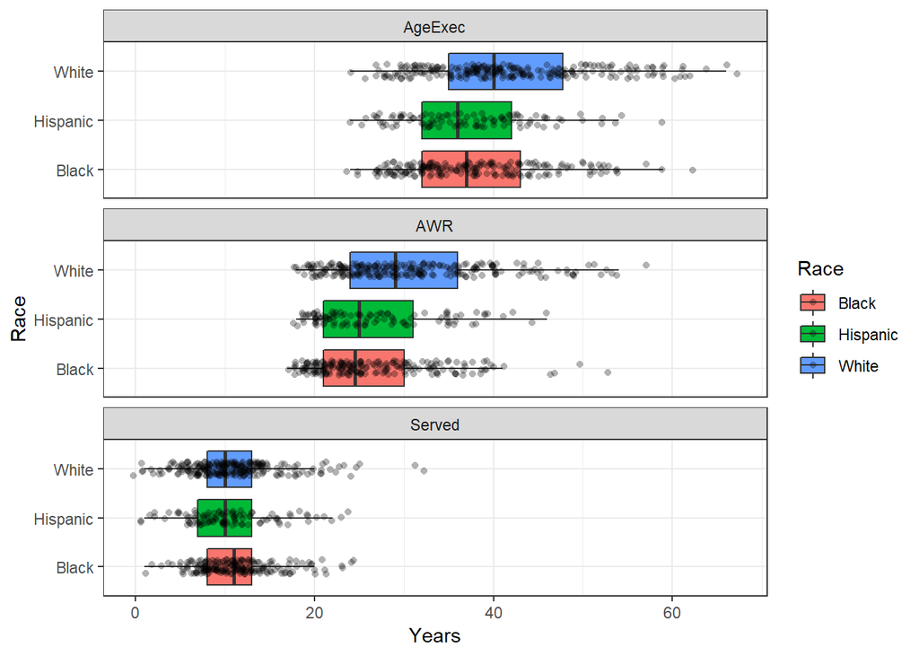

```r
# detailed boxplots of all stats
df <- xCom %>%
  filter(Race != "Other") %>%
  select(Race,AWR,AgeExec,Served)

df <- df %>%
  gather(key = "Age.thingy", value = "Years", colnames(df)[2:4]) %>%
  mutate(Race = factor(Race))

ggplot(data = df, aes(x = Race, y = Years, fill = Race))+
  geom_boxplot(outlier.shape=NA)+
  geom_jitter(shape=16,position=position_jitter(.15),alpha=.3)+
  coord_flip()+
  facet_wrap(~Age.thingy, nrow = 3, strip.position = "top")+
  theme_bw()
```

We see that Blacks tend to be received sooner than Hispanics, while Whites are generally received much later than both other Races. Time served before execution does remain quite similar between all races.

## Victims vs served

Does anything change when the number of victims increases? It’s a bit difficult to make concrete conclusions based on such little data. We can see pretty quickly that most inmates had a single victim. Time served does not seem to fluctuate much based solely on the number of victims: the median seems to stay within the 10 year range we saw before.

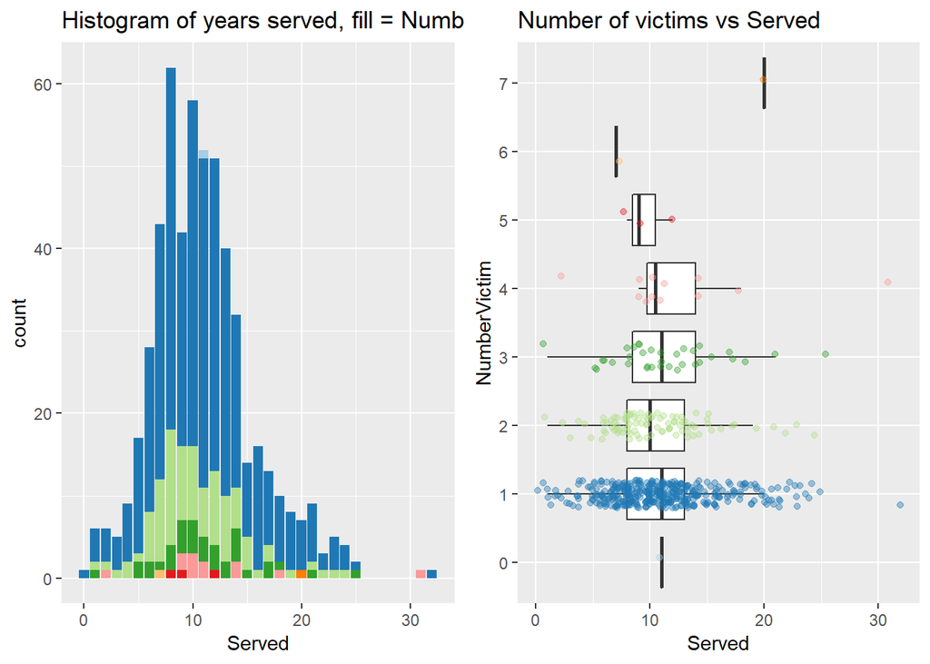

```r
# does time served change as number of victims change?
p3 <- xCom %>%
  # filter(NumberVictim > 0 & NumberVictim < 6) %>%
  ggplot(aes(x=Served,fill=as.factor(NumberVictim)))+
  geom_histogram(stat="count")+
  # facet_wrap(NumberVictim~.,nrow=3)+
  ggtitle("Histogram of years served, fill = NumberVictim")+
  theme(legend.position = "none")+
  scale_fill_brewer(type="qual",palette=3)

# try boxplot instead with numbervictims = box
p4 <- xCom %>%
  as_tibble() %>%
  select(Served, NumberVictim) %>%
  ggplot(aes(y=Served,x=as.factor(NumberVictim)))+
  geom_boxplot(outlier.color = NA)+
  coord_flip()+
  geom_jitter(width=.2,alpha=.4,aes(color=as.factor(NumberVictim)))+
  theme(legend.position = "none")+
  ggtitle("Number of victims vs Served")+
  scale_color_brewer(type="qual",palette=3)+
  xlab("NumberVictim")

grid.arrange(p3,p4,nrow=1)
```

Education level is also relatively constant throughout the range of inmates. In the standard histogram we see a huge dropoff after education level 12 (assumedly High School, grade 12). In fact, our largest peaks occur between grades 9-12, indicating that not completing high school has a potentially significant impact on becoming a deathrow inmate.

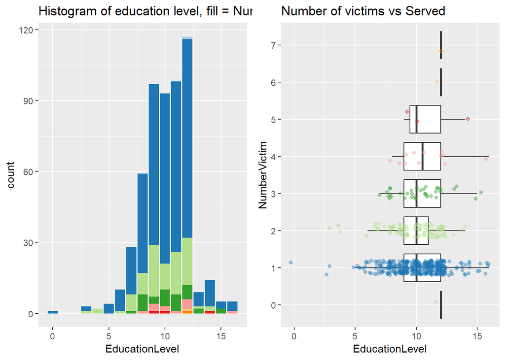

```r
# education level vs number of victims
e1 <- xCom %>%
  # filter(NumberVictim > 0 & NumberVictim < 6) %>%
  ggplot(aes(x=EducationLevel,fill=as.factor(NumberVictim)))+
  geom_histogram(stat="count")+
  # facet_wrap(NumberVictim~.,nrow=2)+
  ggtitle("Histogram of education level, fill = NumberVictim")+
  scale_fill_brewer(type="qual",palette=3)+
  theme(legend.position = "none")

e2 <- xCom %>%
  # as_tibble() %>%
  # select(Served, NumberVictim) %>%
  ggplot(aes(y=EducationLevel,x=as.factor(NumberVictim)))+
  geom_boxplot(outlier.color = NA)+
  # geom_hline(yintercept=12,alpha=.8,linetype="dotted")+
  coord_flip()+
  geom_jitter(width=.2,alpha=.4,aes(color=as.factor(NumberVictim)))+
  theme(legend.position = "none")+
  ggtitle("Number of victims vs Served")+
  scale_color_brewer(type="qual",palette=3)+
  xlab("NumberVictim")

grid.arrange(e1,e2,nrow=1)
```

# NLP

## Unigrams

Single word analysis, when n=1.

### Wordcloud of unigrams by race

Wordclouds give us an easy way to visualize differences in top word choice by race.

#### All

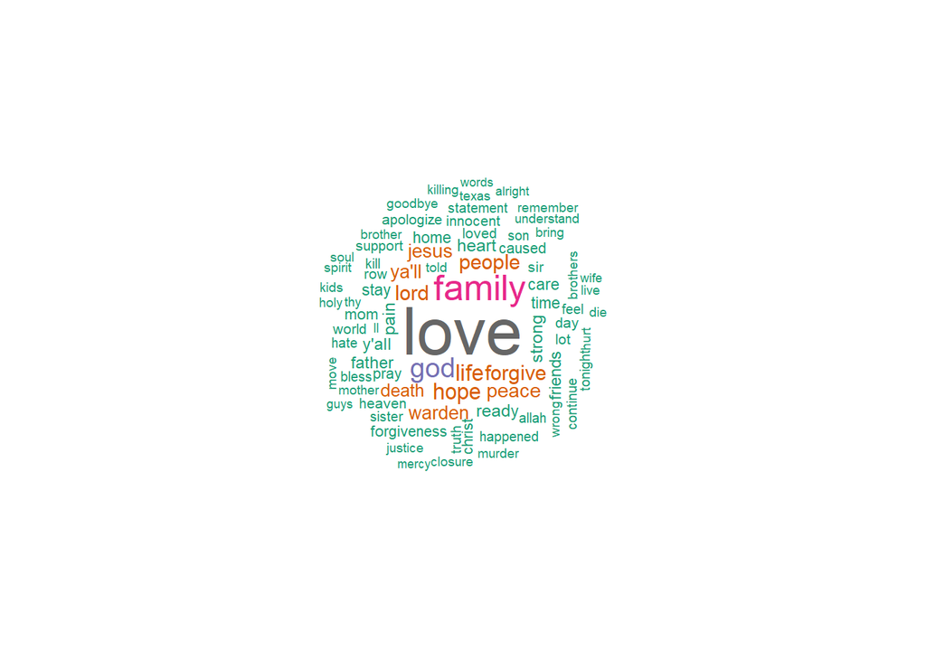

```r
x.unigrams <- x %>%
  filter(Race != "Other") %>%
  select(Race, LastStatement) %>%
  unnest_tokens(unigram,LastStatement,token="ngrams",n=1) %>%
  separate(unigram, c("word1"),sep=" ") %>%
  filter(!word1 %in% stop_words$word) %>%
  unite(unigram,word1,sep=" ")

pal <- brewer.pal(8,"Dark2")

# wordcloud of top used words
x.unigrams %>%
  count(unigram) %>%
  with(wordcloud(unigram,n,
                 max.words=80,
                 min.freq=20,
                 colors=pal,
                 random.order = F,
                 random.color = F,
                 scale=c(3,.5)))
```

#### White

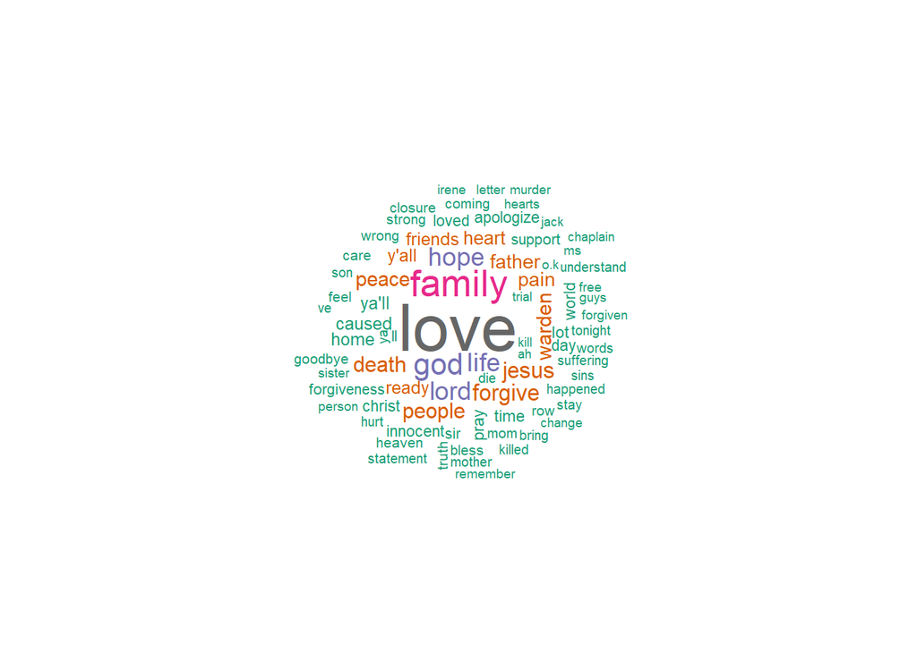

```r
# wordcloud of top used words
x.unigrams %>%
  filter(Race == "White") %>%
  count(unigram) %>%
  with(wordcloud(unigram,n,
                 max.words=80,
                 min.freq=10,
                 colors=pal,
                 random.order = F,
                 random.color = F,
                 scale=c(3,.5)))
```

#### Black

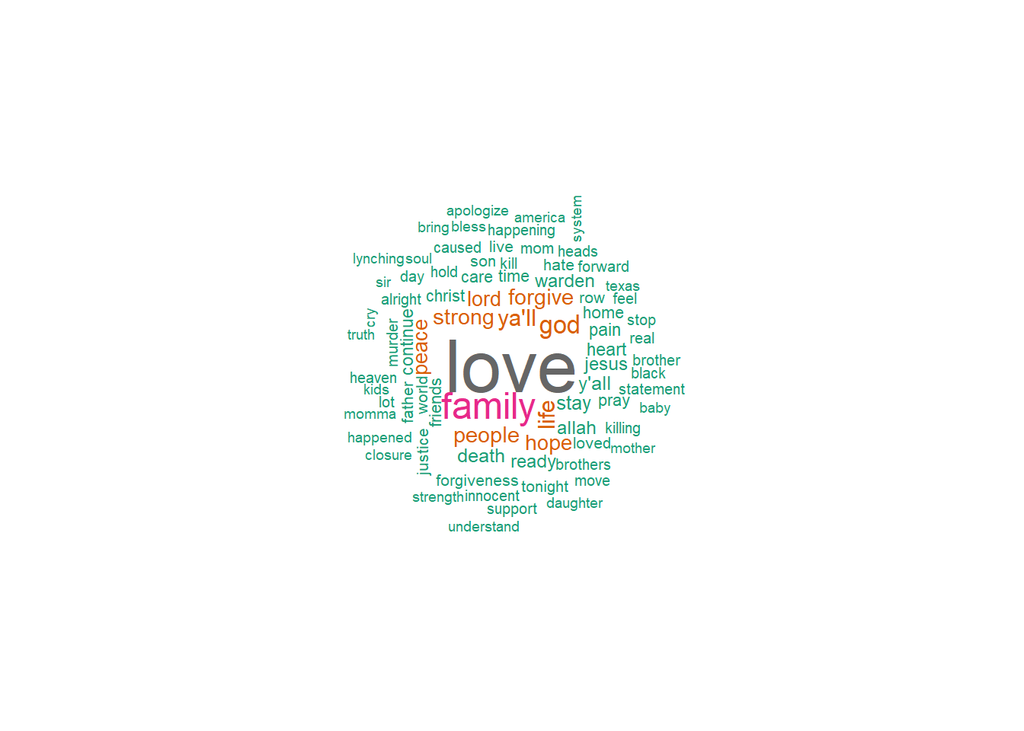

```r
# wordcloud of top used words
x.unigrams %>%
  filter(Race == "Black") %>%
  count(unigram) %>%
  with(wordcloud(unigram,n,
                 max.words=80,
                 min.freq=10,
                 colors=pal,
                 random.order = F,
                 random.color = F,
                 scale=c(3,.5)))
```

#### Hispanic

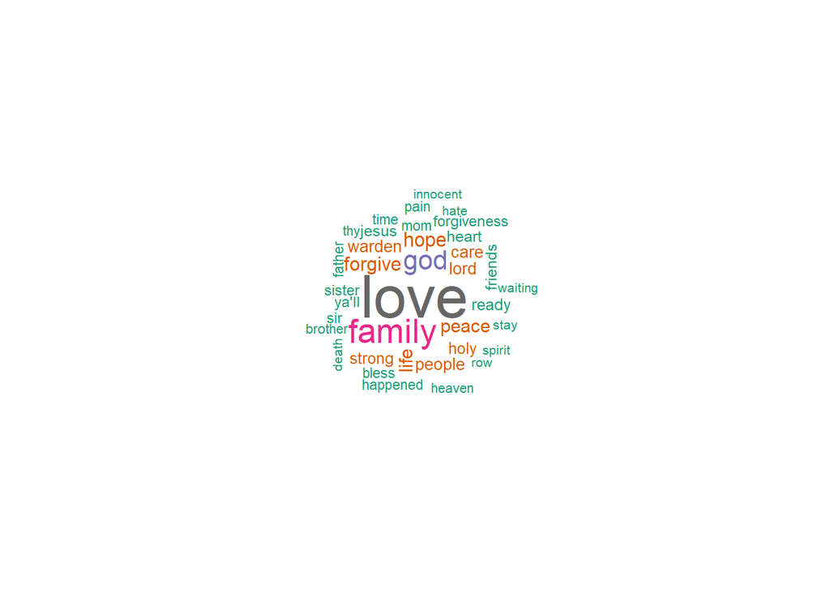

```r
# wordcloud of top used words
x.unigrams %>%
  filter(Race == "Hispanic") %>%
  count(unigram) %>%
  with(wordcloud(unigram,n,
                 max.words=80,
                 min.freq=10,
                 colors=pal,
                 random.order = F,
                 random.color = F,
                 scale=c(3,.5)))
```

### Term frequency

The above wordclouds shows us what words are most common. What if we want to know which words are most unique or most unique between racial subgroups? Term frequency allows us to find this relationship and using inverse document frequency, `tf-idf`, allows us to find words that are common, but not *too* common (Silge and Robinson 2016).

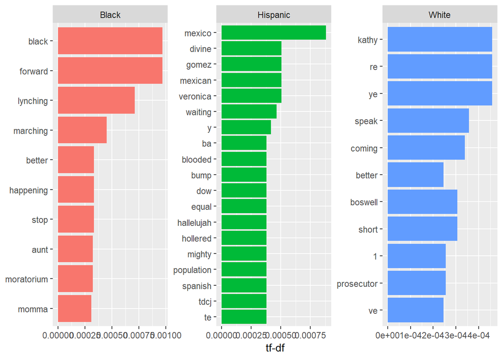

```r
# select statement and race columns
x.1 <- x %>%
  filter(Race != "Other") %>%
  select(Race, LastStatement)

# unnested words used per race
x.2 <- x.1 %>%
  unnest_tokens(word,LastStatement) %>%
  count(Race,word,sort=T) %>%
  ungroup()

# total words used per race
x.3 <- x.2 %>%
  group_by(Race) %>%
  summarise(total=sum(n))

tf.x <- left_join(x.2,x.3) %>%
  bind_tf_idf(word,Race,n)

tf.x %>%
  arrange(desc(tf_idf)) %>%
  mutate(word=factor(word,levels=rev(unique(word)))) %>%
  group_by(Race) %>%
  top_n(10,tf_idf) %>%
  ungroup() %>%
  ggplot(aes(word, tf_idf,fill=Race))+
  geom_col(show.legend=F)+
  labs(x=NULL,y="tf-df")+
  facet_wrap(~Race,scale="free")+
  coord_flip()
```

## Bigrams

Rather quickly, we can look at our most common bigrams.

```r
# collect bigrams
x.bigrams <- x.1 %>%
  unnest_tokens(bigram,LastStatement,token="ngrams",n=2)

# most common bigrams
x.bigrams %>%
  count(bigram,sort=T)
```

| bigram | n |
| --- | --- |
| i love | 576 |
| i am | 523 |
| love you | 397 |
| i have | 228 |
| and i | 220 |
| that i | 207 |
| thank you | 200 |
| i would | 196 |
| you all | 180 |
| all of | 178 |

[output cut: 9990 more lines]

And we can remove stop words to get a better representation of important topics.

```r
# remove stop words occurring in either word pair
x.bigrams.separated <- x.bigrams %>%
  separate(bigram, c("word1","word2"),sep=" ")

x.bigrams.filtered <- x.bigrams.separated %>%
  filter(!word1 %in% stop_words$word) %>%
  filter(!word2 %in% stop_words$word)

# new most common bigrams
x.bigram.counts <- x.bigrams.filtered %>%
  count(word1,word2,sort=T)
x.bigram.counts
```

| word1 | word2 | n |
| --- | --- | --- |
| stay | strong | 52 |
| god | bless | 37 |
| death | row | 36 |
| jesus | christ | 30 |
| lord | jesus | 29 |
| love | ya'll | 29 |
| ready | warden | 23 |
| victim's | family | 20 |
| love | y'all | 18 |
| death | penalty | 14 |

[output cut: 2201 more lines]

Rather than browse lists of popular bigrams we can represent our most popular bigrams in a wordcloud, and also segregate by race to determine if any racial differences exist.

### Wordclouds of bigrams by race

#### All

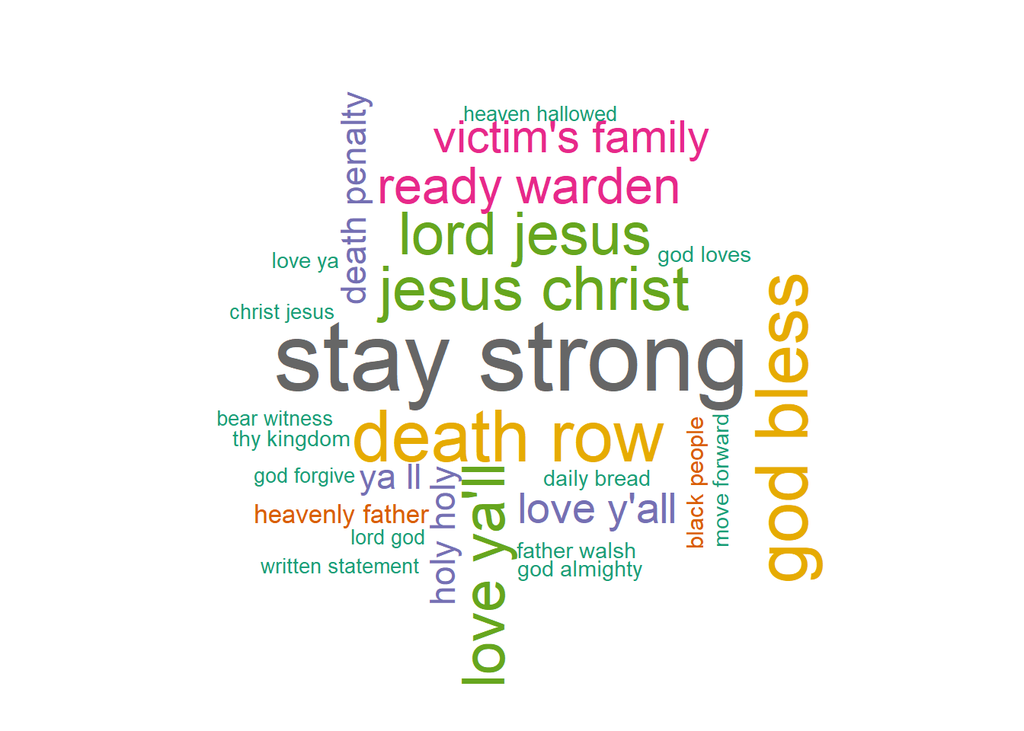

```r
# recombine bigrams without stop words
x.bigrams.united <- x.bigrams.filtered %>%
  unite(bigram,word1,word2,sep=" ")

# wordcloud of most common bigrams ALL
bg.all <- x.bigrams.united %>%
  count(bigram) %>%
  with(wordcloud(bigram,n,
                 max.words=80,
                 min.freq=5,
                 colors=pal,
                 random.order = F,
                 random.color = F,
                 scale=c(4,.5)))
```

#### White

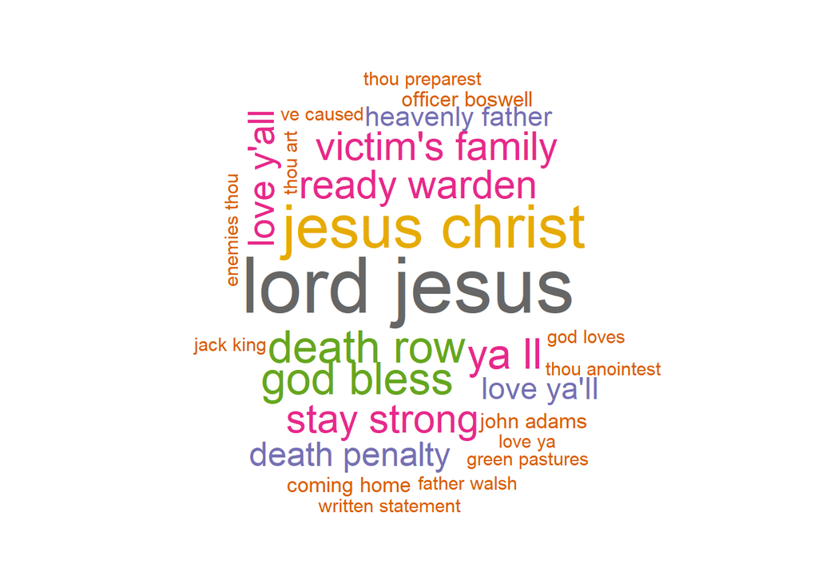

```r
# wordcloud of most common bigrams WHITE
bg.white <- x.bigrams.united %>%
  filter(Race == "White") %>%
  count(bigram) %>%
  with(wordcloud(bigram,n,
                 max.words=80,
                 min.freq=3,
                 colors=pal,
                 random.order = F,
                 random.color = F,
                 scale=c(4,.5)))
```

#### Black

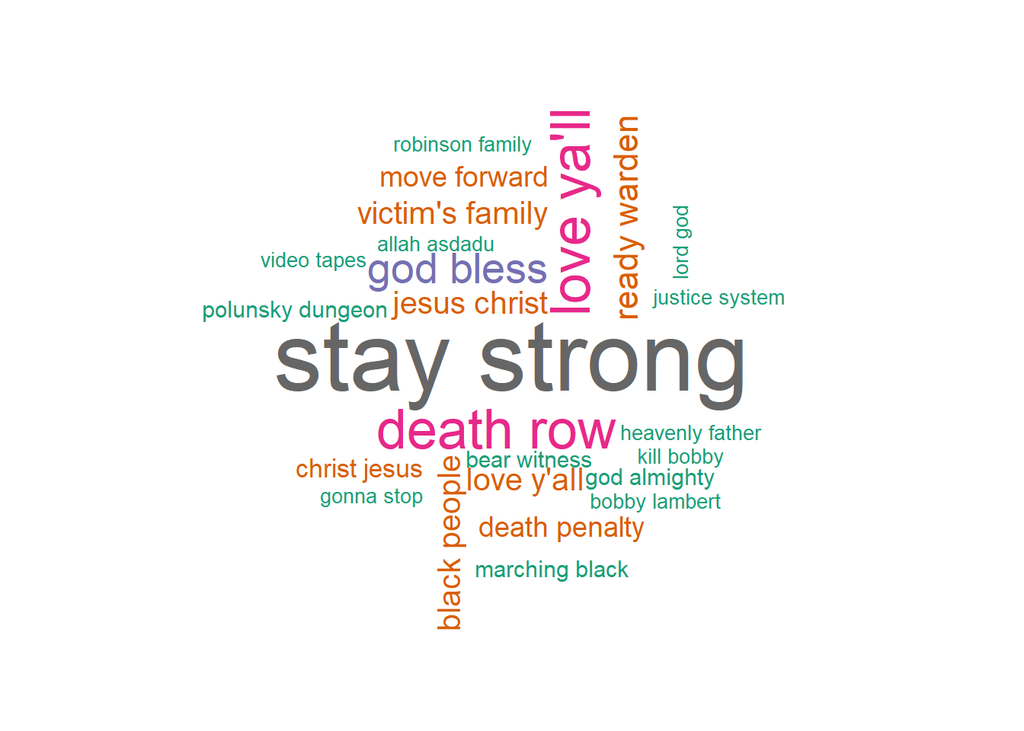

```r
# wordcloud of most common bigrams BLACK
bg.black <- x.bigrams.united %>%
  filter(Race == "Black") %>%
  count(bigram) %>%
  with(wordcloud(bigram,n,
                 max.words=80,
                 min.freq=3,
                 colors=pal,
                 random.order = F,
                 random.color = F,
                 scale=c(4,.5)))
```

#### Hispanic

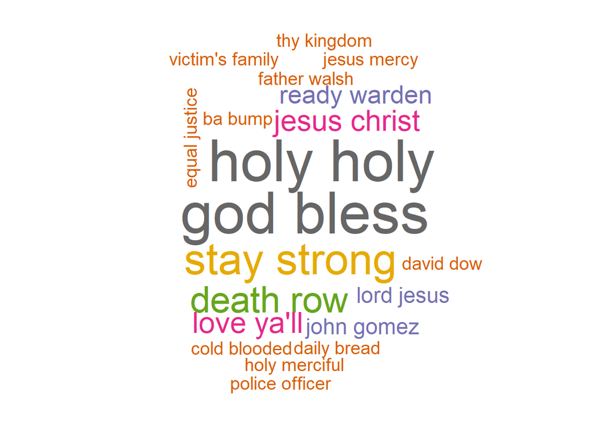

```r
# wordcloud of most common bigrams HISPANIC
bg.hispanic <- x.bigrams.united %>%
  filter(Race == "Hispanic") %>%
  count(bigram) %>%
  with(wordcloud(bigram,n,
                 max.words=80,
                 min.freq=3,
                 colors=pal,
                 random.order = F,
                 random.color = F,
                 scale=c(4,.5)))
```

## Term frequency by race

We can repeat what we did above with our term frequency measure, used on bigrams instead of single words.

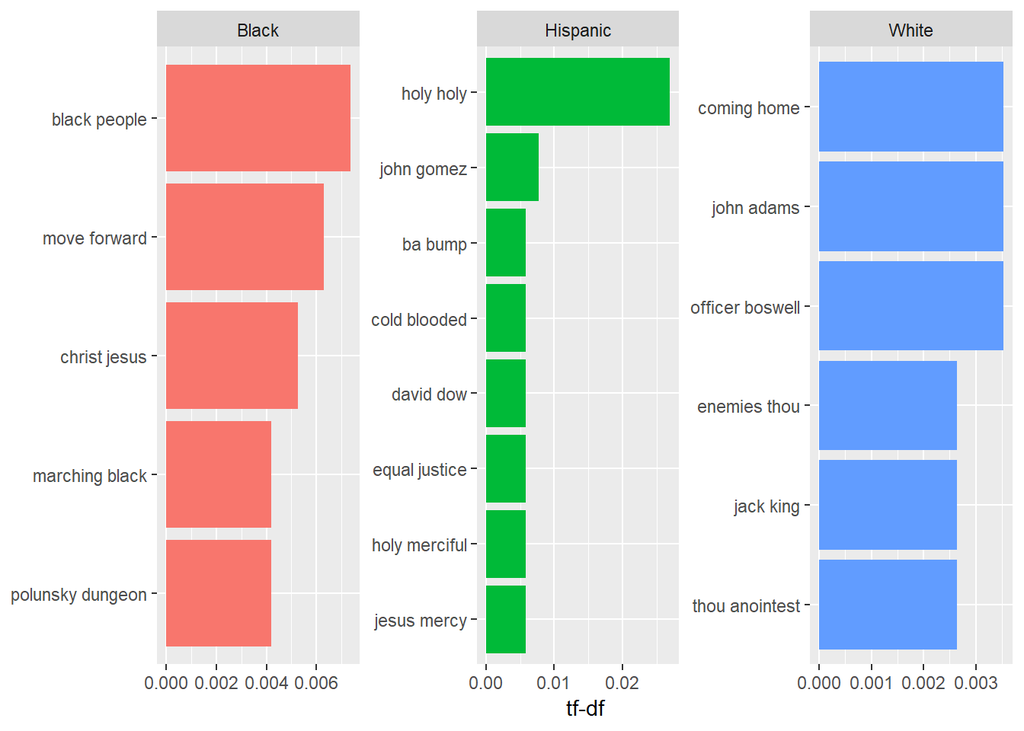

```r
# x.bigrams.filtered %>%
#   filter(word1 == "polunsky") %>%
#   count(Race, word1,sort=T)

x.bigram.tf.idf <- x.bigrams.united %>%
  count(Race,bigram) %>%
  bind_tf_idf(bigram,Race,n) %>%
  arrange(desc(tf_idf))

x.bigram.tf.idf %>%
  filter(Race!="Other") %>%
  arrange(desc(tf_idf)) %>%
  mutate(bigram=factor(bigram,levels=rev(unique(bigram)))) %>%
  group_by(Race) %>%
  top_n(5) %>%
  ungroup() %>%
  ggplot(aes(bigram, tf_idf,fill=Race))+
  geom_col(show.legend=F)+
  labs(x=NULL,y="tf-df")+
  facet_wrap(~Race,scale="free")+
  coord_flip()
```

# Outline

```
Intro
Setup data
  Import
  Impute
  Fix
EDA
  Race vs time served
  Race vs received/executed
  Number of victims vs served
  Education level vs...
NLP
  Words
    Common words - bar
    Common words - wordcloud by race
    Term frequency - bar
    Term frequency - wordcloud by race
  Bigrams
    Common words - bar
    Common words - wordcloud
    Term frequency - bar
    Term frequency - wordcloud
  Trigrams
    Common words - bar
    Common words - wordcloud
    Term frequency - bar
    Term frequency - wordcloud
  Igraph
    Bigram
    Trigram
Conclusion
```

Silge, Julia, and David Robinson. 2016. “Tidytext: Text Mining and Analysis Using Tidy Data Principles in R.” *JOSS* 1 (3). https://doi.org/10.21105/joss.00037.